# AOI for R

Mike Johnson

## Defining an Area of Interest (AOI)

An area of interest (AOI) is a geographic extent. It helps confine the unit of work to a geographic area, and helps to not only prioritize and define research and subsetting efforts, but improves reproducabilty across studies. ’AOI` is an R package that lets users define an AOI through a common query and return a geometry of that area. This is not only usefull for defining a region of interest but aids in subsetting, clipping, and mapping operations:

In principle the AOI package three main task increasing in order of simply providing convenience to providing new functionality to the deep, and broad, R spatial ecosystem. These include helping:

1. Create bounding geometries of existing `sp`, `sf`, and `raster` objects
2. Get `sp`, or `sf`, state and county geometries or their bounding geometries
3. Create `sp` or `sf` geometries from a given location and bounding box dimensions.

Three main parameters can be used to define a query: *state*, *county*, and *clip*. This page illustrates how these parameters can be used define – and refine – a query.

### Installation:

First things first, get up and running in R by downlaoding and installing the `AOI` package:

```r
install.packages("devtools")
library(devtools)
install_github("mikejohnson51/AOI")
```

### Method 1: Defining an AOI by **state**

An AOI can be defined by a **state** name or abbreviation:

```r
CA = getAOI(state = 'CA')
```

[interactive chart not shown]

A query can also be defined by multiple **states** provided as a vector:

```r
WestCoast = getAOI(state = c("Oregon", "Washington", "CA"))
```

[interactive chart not shown]

If you wanted to get the boundaries of a state with the county features intact, simply call getAOI and set county to ‘all’

```r
AL = getAOI(state = "AL", county = 'all')
```

[interactive chart not shown]

### Method 2: Defining an AOI by **county**

Defining an AOI by **county** requires a **state** as well:

```r
EP = getAOI(state = "CO", county = "El Paso")
```

[interactive chart not shown]

Multiple counties can be queried if provided as a vector:

```r
centralCoast = getAOI(state ="CA", county = c("Santa Barbara", "San Luis Obispo", "Ventura"))
```

[interactive chart not shown]

### Method 3: Defining an AOI with a **clip**

In `HydroData` a **clip** is user defined region. Most commonly a bounding box or a supplied shapefile - both of which can be input as a **clip**.

### The clip list()

To define a bounding box **clip** has four inputs given as a list:

1. Location
2. Bounding box height (in miles)
3. Bounding box width (in miles)
4. location origin (default = ‘center’)

Again, all **clip** inputs **must** be provided as a list. It is also important to note that order **DOES** matter if each parameter is not explicitly assigned (eg `h = 10`). Examples for each input follow:

### 1. Location

A Location is the first input in **clip** list and can be given as a colloquial name (*character string*) or as a (lat/long) pair (*numeric*). Names are geocoded by the Google API via the `dismo` R package.

#### *Grand Canyon Location example*:

Here we query an AOI surrounding the Grand Canyon, using both the colloquial name, and the (lat/long) pair found with a [Google search.](http://www.Google.com/search?q=grand+canyon+lat+long) Notice slightly different locations are generated:

```r
GC_name = getAOI(clip = list("grand canyon", 10, 10))

GC_lat_lon = getAOI(clip = list(36.0544, -112.1401, 10, 10))
```

[interactive chart not shown]

### 2. Bounding box height and width

Once a location is specified, the next two needed values are a bounding box height and width (*in miles*). The first entry defines height and the second width:

#### *National Water Center bounding box diminsions example*:

```r
nwc.tall = getAOI(clip = list("National Water Center, AL", 30, 10))
nwc.wide = getAOI(clip = list("National Water Center, AL", 10, 30))
```

[interactive chart not shown]

### 3. Origin

With a location, height, and width defined the relationship of the box to the location is needed. By default (and in the previous examples) each bounding box was generated using the location as a centroid. You can change this by adding a final argument to the **clip** list specifying where the location lies in reference to the box. Options include ‘center’, ‘lowerleft’, ‘lowerright’, ‘upperleft’, ‘upperright’:

#### *UCSB origin example*:

```r
ucsb.c =  getAOI(clip = list("UCSB", 10, 10, "center"))
ucsb.ul = getAOI(clip = list("UCSB", 10, 10, "upperleft"))
ucsb.ur = getAOI(clip = list("UCSB", 10, 10, "upperright"))
ucsb.ll = getAOI(clip = list("UCSB", 10, 10, "lowerleft"))
ucsb.lr = getAOI(clip = list("UCSB", 10, 10, "lowerright"))
```

[interactive chart not shown]

### clip by User Shapefile

A user supplied shapefile can be used as input for the clip parameter in lieu of a list() bounding box.

#### *Santa Monica (user shapefile example)*:

```r
#Read in shapefile of all Los Angeles Communities
LA = rgdal::readOGR("shp/LA.shp", verbose = FALSE)
#Subset Santa Monica
SM = LA[LA$LABEL_CITY == 'Santa Monica',] %>% spTransform(aoiProj)
#Define AOI
AOI = getAOI(clip = SM)
```

[interactive chart not shown]

### Finding and refining an AOI

One on the hardest aspects of defining an AOI is deciding on the query parameters (eg the location, width and height). To help with this the `AOI` package has a `check` function that can be used to define OR refine AOI queries.

If you have no idea about the constraints of your AOI you can run check() alone:

```r
check()
```

[interactive chart not shown]

Doing so brings up a map centered on the United States (panning is available). Zooming to your general AOI, you can use the tools in the lower left hand corner of the map to mark locations to get lat/long, and measure distances. These values can then be input directly into the `getAOI()` call.  
Give it a try!  
The `check()` function can also be chained to existing AOI call to immediately see the region being queried:

```r
getAOI(clip = list("San Luis Obispo", 10, 10 )) %>% check()
```

[interactive chart not shown]

Using the tabs in the upper right corner allow you to toggle between base maps to better understand the area you are defining.  
Give it a try!

## Bounding Box of States / Counties

```r
getAOI(state = "WI", bb = TRUE) %>% check()
```

```
## AOI defined as boundary of Wisconsin
```

[interactive chart not shown]

### Kilometers instead of miles

```r
mi.ex = getAOI(clip = list("UCSB", 10, 10), km = F)
km.ex = getAOI(clip = list("UCSB", 10, 10), km = T)
```

[interactive chart not shown]

### sf instead of sp

As R grows more popular in the spatial community the use of simple feature (sf) objects are becomeing more common. To get you AOI is sf simply set the ‘sf’ parameter to TRUE.

```r
CA.sf = getAOI(state = c('CA', 'NV'), sf = TRUE)
```

```
## AOI defined as boundary of California, and Nevada
```

```r
head(CA.sf)
```

```
## Simple feature collection with 2 features and 5 fields
## geometry type:  MULTIPOLYGON
## dimension:      XY
## bbox:           xmin: -124.4096 ymin: 32.53416 xmax: -114.0399 ymax: 42.00925
## epsg (SRID):    NA
## proj4string:    +proj=longlat +ellps=GRS80 +towgs84=0,0,0,0,0,0,0 +no_defs
##    statefp  statens    affgeoid state_name state_abbr
## 9       06 01779778 0400000US06 California         CA
## 42      32 01779793 0400000US32     Nevada         NV
##                          geometry
## 9  MULTIPOLYGON (((-118.594 33...
## 42 MULTIPOLYGON (((-120.0048 3...
```

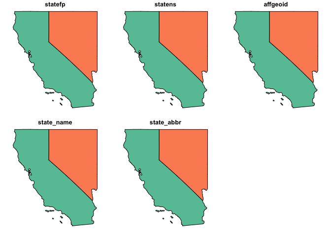

```r
plot(CA.sf, main = nameAOI(state = c('CA', 'NV')))
```

### Use Cases

Now that you know how to define, view and refine an AOI, check out some packages and/or services that are using, or could use the `AOI` package for spatial subsetting calls:  
[HydroData](http://mikejohnson51.github.io/HydroData/)  
[nwm](https://github.com/mikejohnson51/NWM)  
FlowlineFinder  
[FedData](https://cran.r-project.org/web/packages/FedData/index.html)  
nhdplusTools

### Support

Package development is supported with funds from the UCAR COMET program; the NOAA National Water Center; and the University of California, Santa Barbara (UCSB).